# Predicting Obesity Using DASL Dataset

460352996 470066919 480145820 480407614

## Introduction

Excess weight is the new epidemic of the 21st century and has resulted in many significant health and economic consequences for the global population (Stein and Colditz, 2004). In Australia, the obesity epidemic has spread drastically as 1 in 3 adults are classified as overweight or obese (Australian Institute of Health and Welfare, 2019). Researches have shown that this epidemic is more common in males than females and hence, BYU Human Performance Research Center has collected data from 250 men of various age and obtained estimates of the percentage of body fat through underwater weighing and various body circumference measurements (Rahman and Harding, 2013; DASL, n.d.). As body fat percentage is difficult to calculate in real life, the value for body fat percentage was derived from body density using the Siri’s 1956 equation (DASL, n.d.).

### 1.1 Data cleaning and processing

The DASL dataset contain 16 variables including body density, age, body fat percentage and body measurements. The dataset has already been cleaned and for the purpose of this analysis, an additional variable - BMI, has been added where
$$BMI = \frac{Weight (lbs)*703}{Height(in)^2}$$

### 1.2 Sampling Method

Few details were provided with regards to the sampling method. However, from looking at the dataset, there is a gender bias as the epidemic question is one related to both genders, yet only male were involved in the sample. This suggests that any analysis based on this dataset cannot be applied to the whole population but only the male population.

## Analysis

The analysis approach can be broken down into three steps.

### Step 1

Using multiple regression, firstly determine the number of body measurements that is significant in building an accurate prediction model for the three obesity indicators (Body Fat Percentage, BMI and Body Density) individually and how much variation can be explained using only body measurements to examine the ease of calculation.

### Step 2

Compare the end results to determine the best indicator given that body measurements are the only available variables. In each sample, a relative importance test will also be run to determine which body measurement is relatively the most important.

### Step 3

Using BMI as the obesity indicator, a binary indicator will be added to differentiate the sample into overweight individuals (1) and non-overweight individuals (0). A logistic regression is run on the binary indicator with significant variables that we have identified throughout research in order to build a simpler model to determine the odds of an individual being obese.

## Multiple Regression

### Analysis

A correlation matrix is firstly drawn to show the general interactive correlation between variables.

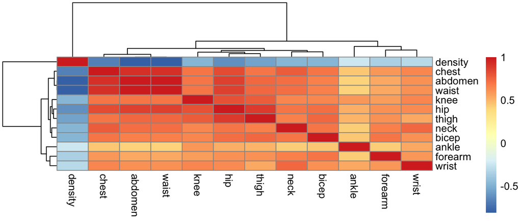

$\textit{Figure 1: Correlation Matrix}$

Notably, waist, chest, abdomen are showing highly correlated relationships, and this may be due to the fact that they are from a similar body area. Hence, body measurements that are from similar areas are classified and linked together using the above graph.

All three obesity indicator follow a similar procedure for multiple regression analysis.

Backward stepwise model was used for body fat and BMI where a full model was selected at the start. The least informative variables were dropped using AIC until only the most relevant variables remain and a final fitted model is achieved. A forward variable selection method was used for body density and a null model was selected at the beginning with subsquent addition of the most statistically signicant variable. The final fitted model is formed when no further addition is required.

For the analysis of BMI, a transformation using log was required. However, as BMI is measured in unit increase, the interpretation of percentage changed is unreasonable. Hence, the non-transformed model was used as the final fitted model.

Assumptions for normality and homoskedasticity were checked via residuals plots and QQ plot. Then the predictor variable plots were drawn for illustrating the relative importance of the remaining variables.

### Results

The final fitted models for the three obesity indicators were:
$$\begin{aligned}
&\hat{Body Fat} = 1.52 -0.3965Neck - 0.128Chest\\
&+ 1.01805Abdomen -0.28758Hip + 0.26Bicep -1.55084Wrist\\
&\hat{BMI} = -10.94 +0.161Chest + 0.127Abdomen\\
&+ 0.050Hip + 0.150Thigh - 0.23Knee + 0.115Forearm\\
&\hat{Body Density} = 1.1104052 + 0.0019085 Neck\\
&- 0.0022064Abdomen + 0.0011314 Hip - 0.0006094 Thigh\\
\end{aligned}$$

BMI was identified as the best obesity indicator given only body measurements as 90.2% of its variation can be explained using solely body measurements compared to 73.5% for Body Fat Percentage and 70.4% for Body Density.

## Logistic Regression

### Analysis

A binary logistic regression was used to calculate the probability of a person being overweight where overweight is indicated by a BMI greater or equal to 25. Similar to the multiple regression analysis, a backward stepwise selection method is also utilised to determine a final classification model.

Using the model, the probability of an individual being obese is then derived using a confusion matrix where its performance as a predictive model is evaluated.

### Results

The final classification model is
$$\begin{aligned}
logit(p)=log(\frac{p}{1-p})=-75.89380+0.37854Chest\\ +0.27128Abdomen+0.22381Thigh
\end{aligned}$$

The results of this model is visualised by Figure 2 through the sigmoid function. The predicted values to probabilities are mapped between 0 and 1. For predictions of 0.5 and above, these are classifed as people who are overweight. Whereas predictions of below 0.5 are classified as people who are non-overweight.

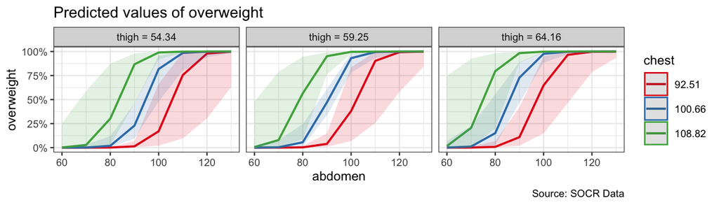

$\textit{Figure 2: Predicted value of overweight}$

A confusion matrix is created to derive the performance of our classification model.

```
##           Reference
## Prediction   0   1
##          0 117  12
##          1   8 113
```

The accurate and inaccurate predictions are the diagonal and non-diagonal values respectively. For this model, there are 117 + 113 accurate predictions, and 12 + 8 are inaccurate predictions.

Along with an accuracy of 92%, we summarise that this new simplified model is, therefore, a good predictive model.

A decision tree on the variables abdomen and chest is represented by Appendix C. Out of a total of 250 observations, 96% of people with a chest circumference greater or equal to 101.55cm are overweight. Also, of the people with a chest circumference less than 101.55cm, those with an abdomen circumference greater or equal to 92.6cm are 72% likely to be overweight. On the other hand, those with an abdomen circumference less than 92.6cm are 92% likely to be non-overweight.

## Limitations

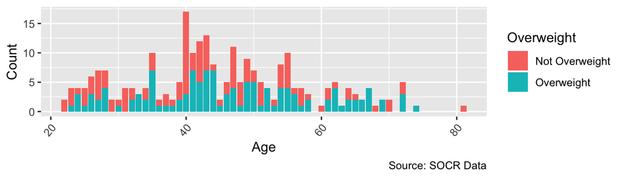

$\textit{Figure 3:Obesity across different age groups}$

### 4.1 Gender bias

The data is taken from 250 males without any record of females. Therefore, the result of this analysis can only be applied to the male population rather than the entire population in general.

### 4.3 Multicollinearity

Several variables from the dataset are highly dependent, with the most significant correlation between waist and abdomen. Through plotting the points into a QQ-Plot, it is evident that all points are closely sitting on the line. Hence, during model selection, waist was dropped to prevent multicollinearity.

## Conclusion

Through multiple regression and variable selection, a fitted model with solely body measurements was determined for each of the three obesity indicators. Using $R^2$, BMI was identified as the best indicator as it has the highest proportion of variance that can be explained using only body measurements.

By separating the dataset with the binary variable for over-weight individuals, a simplified prediction model with 92% accuracy was built. The simplified model contains three body measurements - chest, abdomen and thigh, and should be relatively simpler to measure.

## Reference List

### 1.

Australian Institute of Health and Welfare (AIHW). (2019). Overweight & obesity. Australian Government. Retrieved from https://www.aihw.gov.au/reports-data/behaviours-risk-factors/overweight-obesity/overview

### 2.

DASL. (n.d.). Bodyfat. DASL. Retrieved from https://dasl.datadescription.com/datafile/bodyfat

### 3.

Rahman, A., & Harding, A. (2013). Prevalence of overweight and obesity epidemic in Australia: some causes and consequences. JP Journal of Biostatistics, 10(1), 31-48.

### 4.

Stein, C. J., & Colditz, G. A. (2004). The epidemic of obesity. The Journal of Clinical Endocrinology & Metabolism, 89(6), 2522-2525.

### 5.

Avinash, N. (2018). Understanding Logistic Regression in Python. DataCamp. Retrieved from https://www.datacamp.com/community/tutorials/understanding-logistic-regression-python

### 6.

Nagesh S. C. (n.d.). Real world implementation of Logistic Regression. Medium. Retrieved from https://towardsdatascience.com/real-world-implementation-of-logistic-regression-5136cefb8125

## Appendices

### Appendix A - Multiple Regression: Relative Importance of Predictors

```
##           Weights
## wrist    4.038431
## bicep    7.746760
## neck     8.238378
## hip     16.313788
## chest   21.795458
## abdomen 41.867184
```

```
##           Weights
## forearm  9.021850
## knee     9.080285
## thigh   15.075099
## hip     17.245099
## abdomen 24.705834
## chest   24.871833
```

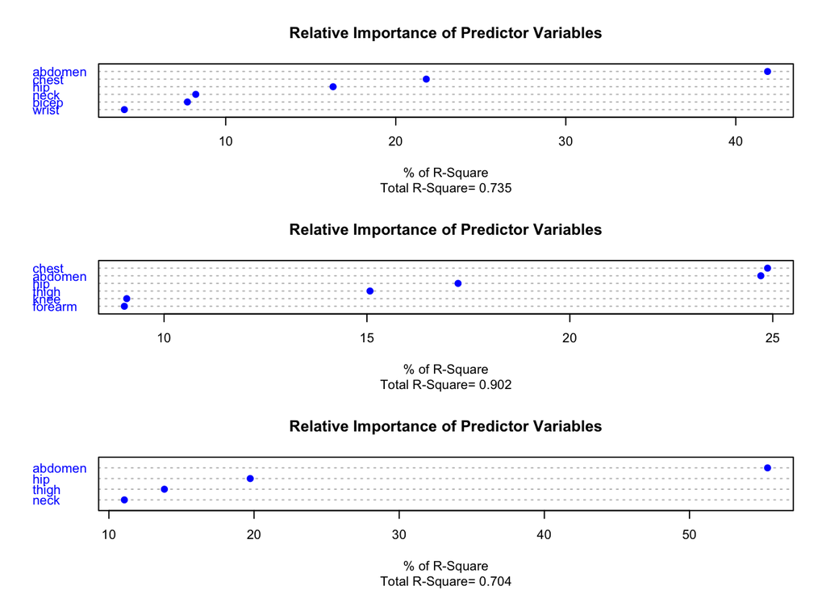

```
##          Weights
## neck    11.06366
## thigh   13.82063
## hip     19.73563
## abdomen 55.38008
```

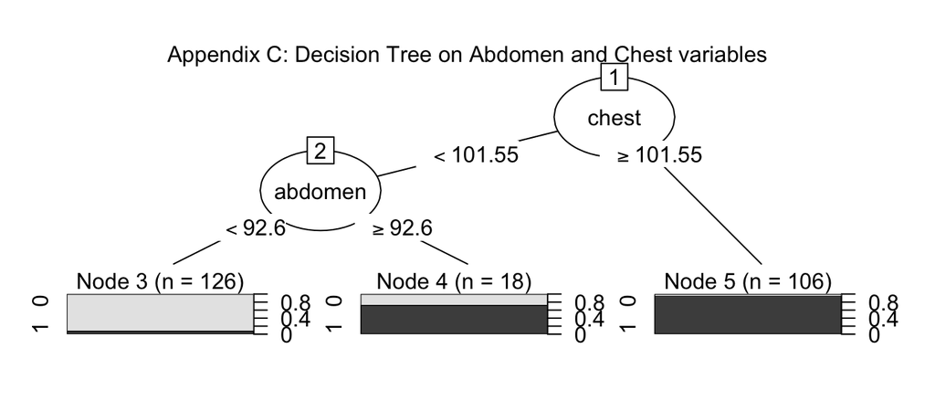